# Computer Vision Project

DOMAIN: Botanical research

#### CONTEXT: University X is currently undergoing some research involving understanding the characteristics of plant and plant seedlings at various stages of growth. They already have have invested on curating sample images. They require an automation which can create a classi ier capable of determining a plant's species from a photo

• DATA DESCRIPTION: The dataset comprises of images from 12 plant species. Source: https://www.kaggle.com/c/plant-seedlings-classiication/data

PROJECT OBJECTIVE: University’s management require an automation which can create a classifier capable of determining a plant's species from a photo Steps and tasks:

1. Import the data. Analyse the dimensions of the data. Visualise the data.
2. Design, train tune and test the best AIML image classi ier model using: • Supervised learning algorithms • Neural networks • CNN
3. Compare the results from the above step along with your detailed observations on the best performing algorithm and why/how it outperforms other algorithms in this case.
4. Pickle the best performing model.
5. Import the the test image [ from the “ Prediction” folder ] to predict the class. Display the image. Use the best trained image classi ier model to predict the class.

```python
#!pip install tensorflow-gpu
#!pip install google
#!pip install protobuf
#!pip install google-cloud
#!conda update --all -y
#!pip uninstall tf-nightly --yes
#!pip uninstall tf-estimate-nightly --yes
#!pip install update tensorflow
#!pip install tensorflow==2.1
#!pip install keras==2.3.1
```

```python
import numpy as np
import pandas as pd
import tensorflow as tf
import warnings
warnings.filterwarnings('ignore')
```

[output not shown]

```python
tf.__version__
```

```
'2.1.0'
```

```python
from tensorflow import keras
#from keras.preprocessing import image_dataset_from_directory
#from keras.preprocessing.image import ImageDataGenerator
#import tf.keras.preprocessing.image_dataset_from_directory
#from tensorflow.keras.preprocessing import image_dataset_from_directory
#from tensorflow.keras.preprocessing.image import image_dataset_from_directory
#import tensorflow.keras.preprocessing.image.ImageDataGenerator
import matplotlib.pyplot as plt
from matplotlib import gridspec
import pathlib
import PIL
import PIL.Image
from tensorflow.keras.callbacks import EarlyStopping, LearningRateScheduler
from tensorflow.keras import Sequential
from tensorflow.keras.layers import Flatten,BatchNormalization,MaxPooling2D,Dropout, Convolution2D, Dense
```

```python
#!pip install splitfolders
file_name = "Part-1 - Plant Seedling Classification Data-20211019T085254Z-001.zip"
import zipfile as zf
train_zip = zf.ZipFile(file_name)
train_zip.extractall()
!ls
```

```
'Computer Vision Project_Hemlata-Copy1.ipynb'
'Computer Vision Project_Hemlata.ipynb'
'CV 1 - Project.pdf'
 Data
 Data2
 Data3
 NN_model1.h5
 output
 Output
'Part-1 - Plant Seedling Classification Data'
'Part-1 - Plant Seedling Classification Data-20211019T085254Z-001'
'Part-1 - Plant Seedling Classification Data-20211019T085254Z-001.zip'
 Predict.png
```

```python
!ls 'Part-1 - Plant Seedling Classification Data/train'
```

```
 Black-grass	    'Common wheat'	'Scentless Mayweed'
 Charlock	    'Fat Hen'		'Shepherds Purse'
 Cleavers	    'Loose Silky-bent'	'Small-flowered Cranesbill'
'Common Chickweed'   Maize		'Sugar beet'
```

```python
import splitfolders
```

```python
splitfolders.ratio('Part-1 - Plant Seedling Classification Data/train', output="Output", seed=1337, ratio=(.8,.0,0.2))
```

```
Copying files: 4767 files [01:04, 73.94 files/s]
```

#### Steps and tasks: [ Total Score: 10 points]

### 1. Import data.

```python
all_images_path = 'Part-1 - Plant Seedling Classification Data/train'
all_images_path = pathlib.Path(all_images_path)
all_images_count = len(list(all_images_path.glob('*/*.png')))
print(all_images_count)
train_img_path = 'Output/train'
train_img_path = pathlib.Path(train_img_path)
train_image_count = len(list(train_img_path.glob('*/*.png')))
print(train_image_count)
test_img_path = 'Output/test'
test_img_path = pathlib.Path(test_img_path)
test_image_count = len(list(test_img_path.glob('*/*.png')))
print(test_image_count)
```

```
4767
3864
1009
```

```python
categories = ['Black-grass', 'Charlock', 'Cleavers', 'Common Chickweed', 'Common wheat', 'Fat Hen', 'Loose Silky-bent',
              'Maize', 'Scentless Mayweed', 'Shepherds Purse', 'Small-flowered Cranesbill', 'Sugar beet']
num_categories = len(categories)
print(num_categories)
```

```
12
```

```python
from keras.preprocessing import image
from tqdm import tqdm
import os
```

```python
data_dir = 'Output'
train_dir = os.path.join(data_dir, 'train')
test_dir = os.path.join(data_dir, 'test')
```

```python
for category in categories:
    print('{} {} images'.format(category, len(os.listdir(os.path.join(train_dir, category)))))
```

```
Black-grass 218 images
Charlock 321 images
Cleavers 233 images
Common Chickweed 495 images
Common wheat 176 images
Fat Hen 382 images
Loose Silky-bent 539 images
Maize 176 images
Scentless Mayweed 424 images
Shepherds Purse 187 images
Small-flowered Cranesbill 404 images
Sugar beet 309 images
```

```python
train = []
for category_id, category in enumerate(categories):
    for file in os.listdir(os.path.join(train_dir, category)):
        train.append(['train/{}/{}'.format(category, file), category_id, category])
train = pd.DataFrame(train, columns=['file', 'category_id', 'category'])
train.shape
```

```
(3864, 3)
```

```python
test = []
for category_id, category in enumerate(categories):
    for file in os.listdir(os.path.join(test_dir, category)):
        test.append(['test/{}/{}'.format(category, file), category_id, category])
test = pd.DataFrame(test, columns=['file', 'category_id', 'category'])
test.shape
```

```
(1009, 3)
```

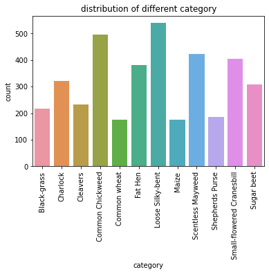

```python
import seaborn as sns
sns.countplot(x='category',data=train).set_title('distribution of different category');
plt.xticks(rotation=90);
```

```python
from PIL import Image
import os, sys

path = "Output/train"
dirs = os.listdir( path )

def resize():
    for item in dirs:
        if os.path.isfile(path+item):
            im = Image.open(path+item)
            f, e = os.path.splitext(path+item)
            imResize = im.resize((64,64), Image.ANTIALIAS)
            imResize.save(f+'.png', 'png', quality=80)

resize()
```

```python
path = "Output/test"
dirs = os.listdir( path )
resize()
```

```python
def read_img(filepath, size):
    img = image.load_img(os.path.join(data_dir, filepath), target_size=size)
    img = image.img_to_array(img)
    img = np.array(img)
    return img
```

```python
x_train=[]
for file in tqdm(train['file']):
    img = read_img(file, (64, 64))
    x_train.append(img)
```

```python
x_train=np.array(x_train)
x_train.shape
```

```
(3864, 64, 64, 3)
```

```python
x_test=[]
for file in tqdm(test['file']):
    img=read_img(file,(64,64))
    x_test.append(img)
x_test=np.array(x_test)
```

```python
x_test.shape
```

```
(1009, 64, 64, 3)
```

```python
test.head()
```

|  | file | category_id | category |
| --- | --- | --- | --- |
| 0 | test/Black-grass/42336b187.png | 0 | Black-grass |
| 1 | test/Black-grass/abe0f4751.png | 0 | Black-grass |
| 2 | test/Black-grass/d6036a0f4.png | 0 | Black-grass |
| 3 | test/Black-grass/4cd2a07dd.png | 0 | Black-grass |
| 4 | test/Black-grass/d441eeda3.png | 0 | Black-grass |

```python
y_train=train['category_id']
y_train.shape
```

```
(3864,)
```

```python
y_test=test['category_id']
y_test.shape
```

```
(1009,)
```

```python
from sklearn.preprocessing import LabelBinarizer
label_binarizer = LabelBinarizer()
label_binarizer.fit(y_train)
y_train=label_binarizer.transform(y_train)
```

```python
y_train.shape
```

```
(3864, 12)
```

```python
label_binarizer.fit(y_test)
y_test=label_binarizer.transform(y_test)
```

```python
y_test.shape
```

```
(1009, 12)
```

```python
## load files
from sklearn.datasets import load_files
from PIL import Image
import matplotlib.pyplot as plt
import seaborn as sns
from mpl_toolkits.axes_grid1 import ImageGrid
from keras.preprocessing import image
path="Output/train"

data = load_files(path)

files = np.array(data['filenames'])
#targets = np_utils.to_categorical(np.array(data['target']), 12)

## Make data frame with each file & label
df = pd.DataFrame({'label': data.target, 'file': data.filenames})
```

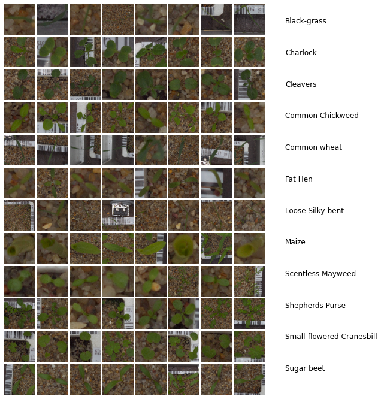

```python
def read_img(filepath, size):
    """
    Load images from files into array (using keras.image)
    """
    img = image.load_img(filepath, target_size=size)
    img = image.img_to_array(img)
    return img

## Display Representative thumbnails of each species
fig = plt.figure(1, figsize=(12,12))
grid = ImageGrid(fig, 111, nrows_ncols=(12,8), axes_pad=0.05)
i = 0
for category_id, category in enumerate(categories):
    for filepath in df[df['label'] == category_id]['file'].values[:8]:
        #print(filepath)
        ax = grid[i]

        img = read_img(filepath, (64, 64))
        ax.imshow(img / 255.)
        ax.axis('off')
        if i % 8 == 2:
            ax.text(450, 40 - i*0.3, filepath.split('/')[2],fontsize=12)
        i += 1
plt.show();
```